# Homework 1

Ahmet Pala

18 October 2018

#### 1.) Introduction

Sports forecasting is a very common and important issue recently since there are several people interested in sports competitions. More than that, some people are sports fanatic. Therefore, people are curious about the match results and there are some companies determining the odds for corresponding games and people can bet on sport competitions. These companies (i.e. Bookmakers) consider the properties of teams and other parameters, then they determine the odds for corresponding matches. This project was carried out for examining the effectiveness of different bookmakers about determining different types of odds. During this project, the data of England Premier League was used to analyze the bookmakers’ behaviors.

#### 2.) Task 1

#### 2.1.) Task 1.a

In this part, 5 of bookmakers were selected for analyzing their behaviors about determining over odds. The implied probabilities and the fractions were calculated for both initial and final over odds for each bookmaker. For a successful performance, it is expected that the points are around y=x lines.

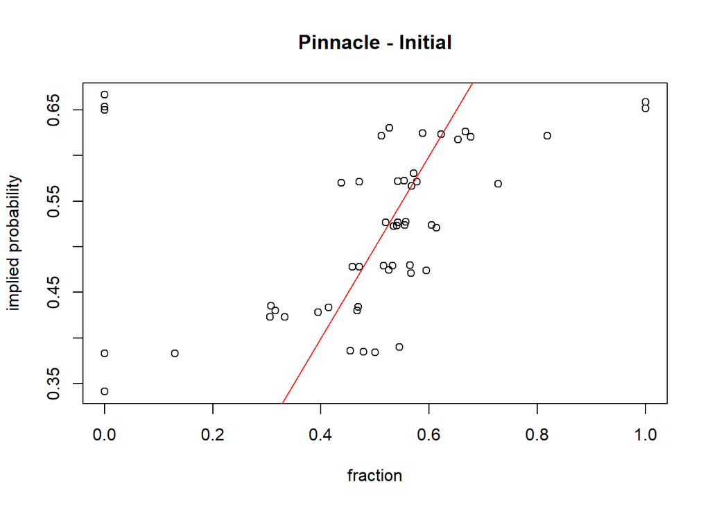

*Figure 1: Fraction vs implied values for initial over odds of Pinnacle*

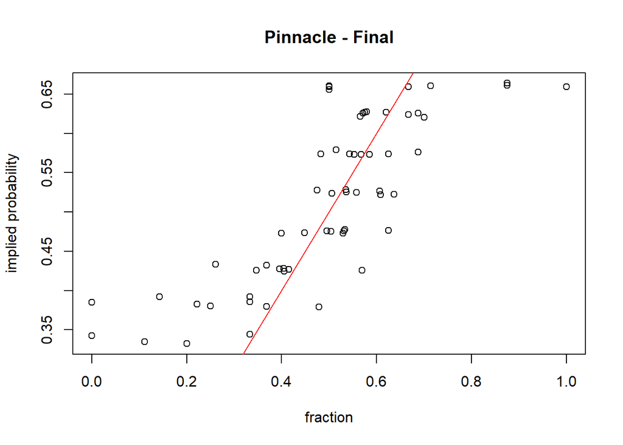

*Figure 2: Fraction vs implied values for final over odds of Pinnacle*

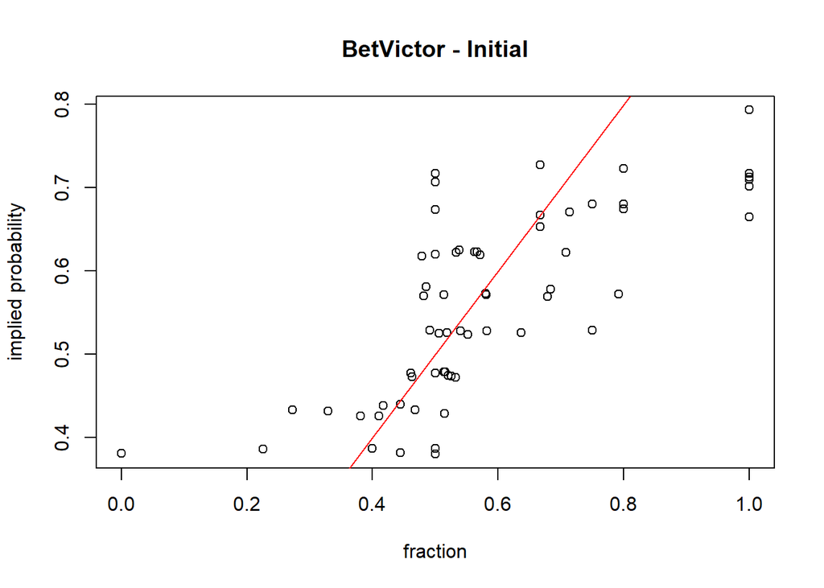

*Figure 3: Fraction vs implied values for initial over odds of BetVictor*

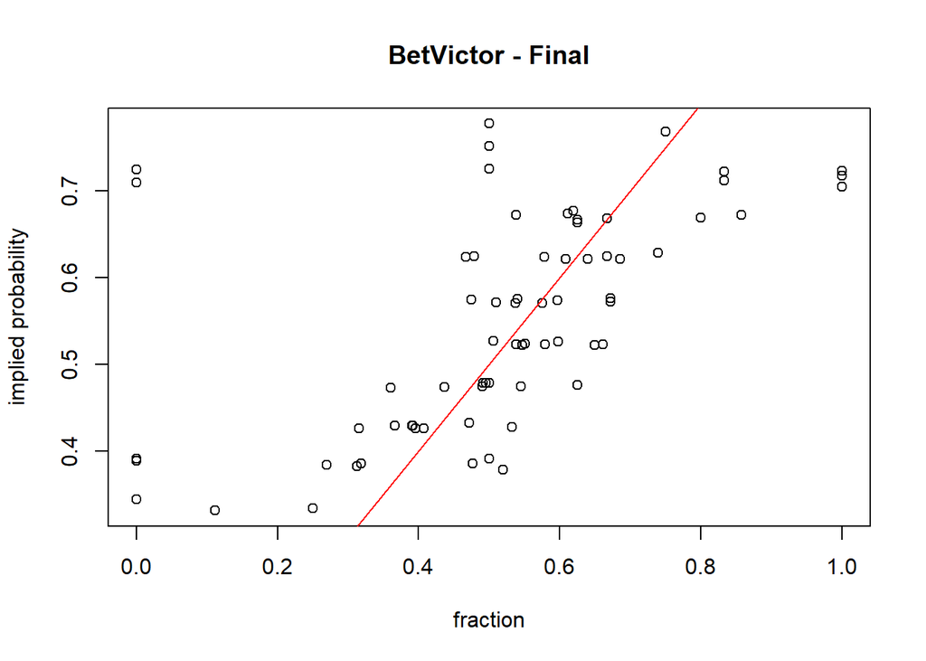

*Figure 4 : Fraction vs implied values for final over odds of BetVictor*

In general, BetVictor can predict whether the matches will finish as over since the points are around y=x line in general. For the starting odds, BetVictor is slightly more effective around the fraction values 0.4 and 0.55 while for the final odds, it is more successful about prediction around the fraction values 0.4 and 0.65. Moreover, it can be said that after changing its odds (from starting odd to final odd), it can predict match result (over or not) more accurately since the points in figure 4 are more close to y=x line.

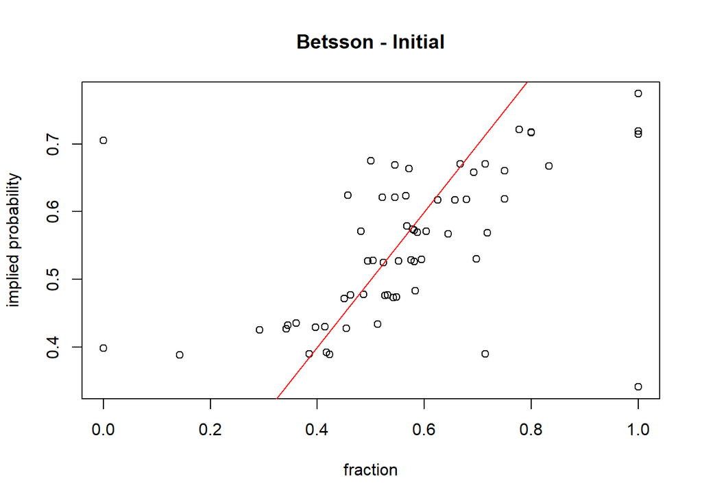

*Figure 5 : Fraction vs implied values for initial over odds of Betsson*

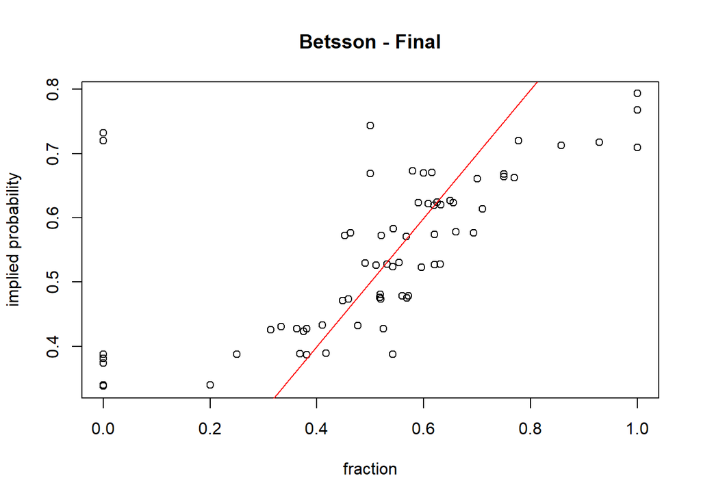

*Figure 6 : Fraction vs implied values for final over odds of Betsson*

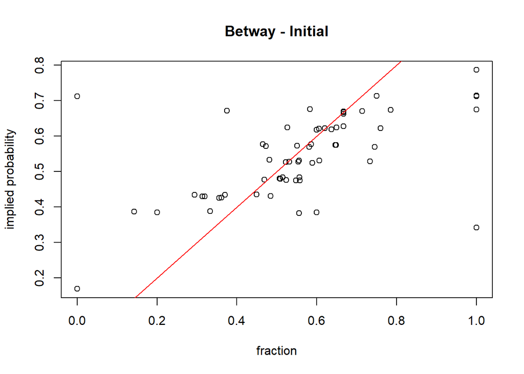

*Figure 7 : Fraction vs implied values for initial over odds of Betway*

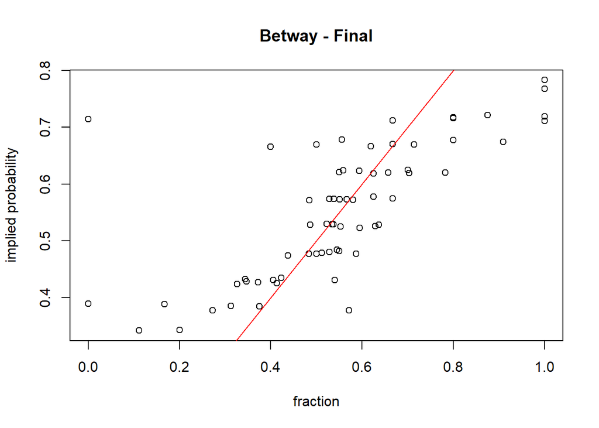

*Figure 8 : Fraction vs implied values for final over odds of Betway*

For the bookmaker Betway, the starting odds are more accurate around the fraction 0.4 and 0.65. On the other hand, its predictions become better after changing its odds (final odds) around the fraction values between 0.4 and 0.75.

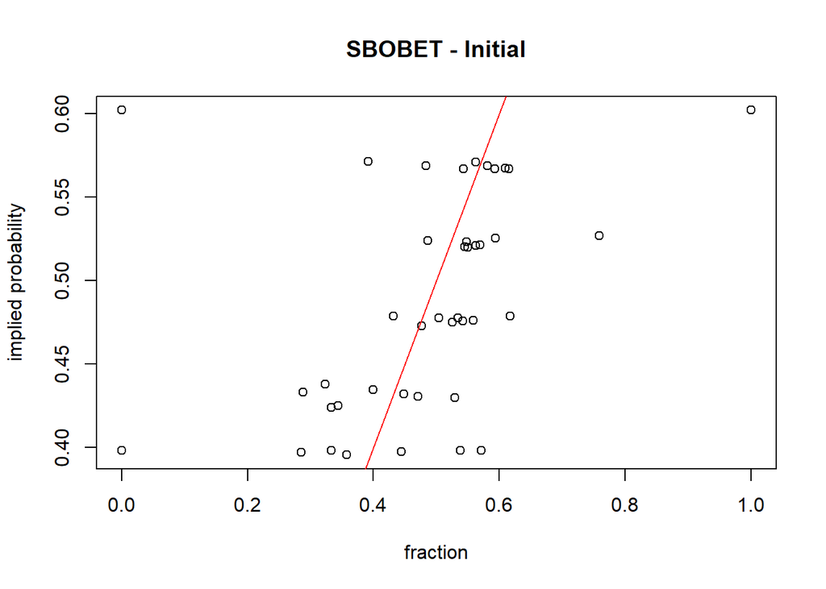

*Figure 9 : Fraction vs implied values for initial over odds of SBOBET*

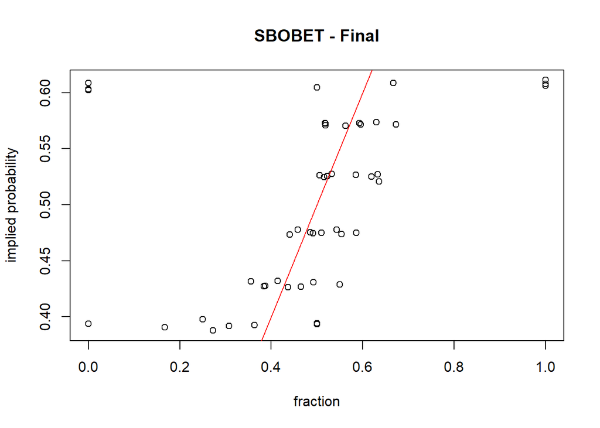

*Figure 10 : Fraction vs implied values for final over odds of SBOBET*

The bookmaker SBOBET can be claimed as less successful about predicting whether the match will finish as over than the previous 4 bookmakers. Moreover, after changing its odds (from starting odd to final odd), its predictions become better. However, this improvement is again less sufficient than the previous 4 bookmakers. Therefore, it can be said that SBOBET is not a successful bookmaker compared to previous 4 bookmakers.

#### 2.2.) Task 1.b

In this task, the same data was used for analyzing the performance of the bookmaker. The bookmaker Pinnacle was selected as the test bookmaker to analyze the accuracy of its over odds. Its implied probabilities was divided into bins and its performance for each bin was observed along years. The plots were drawn for each bin. However, in some cases there was not enough data to examine the performance of bookmaker. Therefore, some bins were combined and the recommendations were made based on combined data. It is expected to see that the fractions are in the corresponding bin for a good bookmaker.

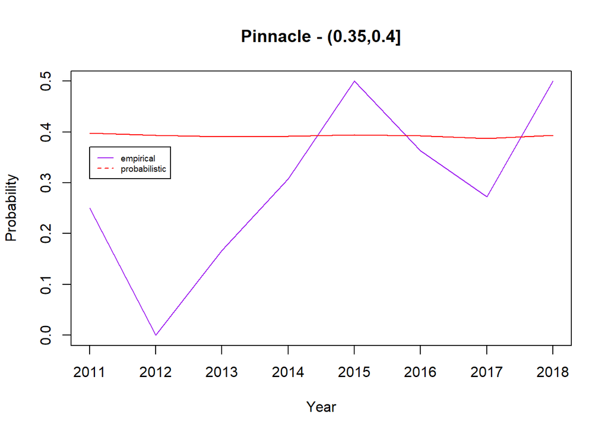

*Figure 11 : Fraction (empirical) vs implied probability (probabilistic) for Pinnacle for corresponding bin.*

Since the data ( total number of matches ) for corresponding bin shown in Figure 11 is too small, the variation between fraction and implied probability is large. Therefore it cannot be meaningful to consider this bin for determining the accuracy of the bookmaker Pinnacle.

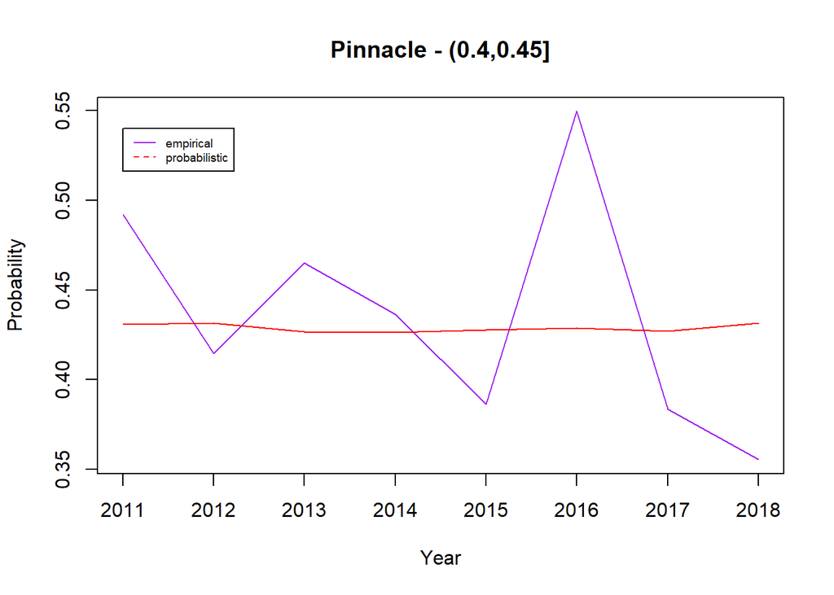

*Figure 12 : Fraction (empirical) vs implied probability (probabilistic) for Pinnacle for corresponding bin.*

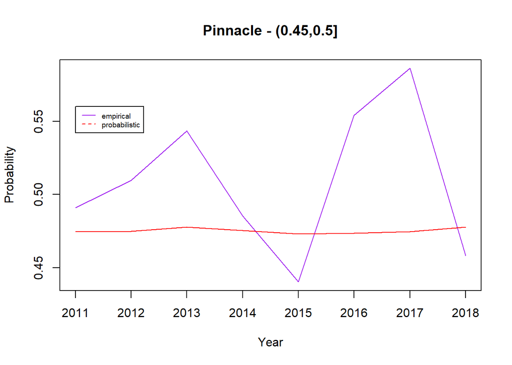

*Figure 13 : Fraction (empirical) vs implied probability (probabilistic) for Pinnacle for corresponding bin.*

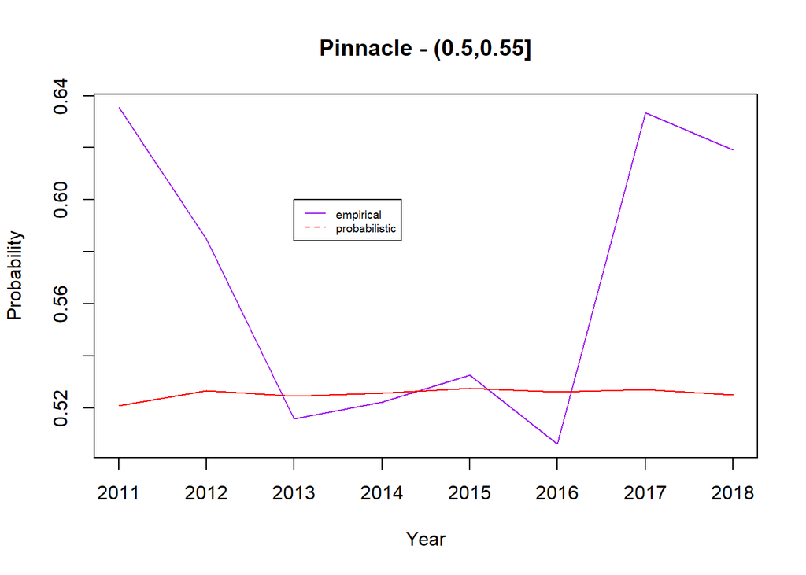

*Figure 14 : Fraction (empirical) vs implied probability (probabilistic) for Pinnacle for corresponding bin.*

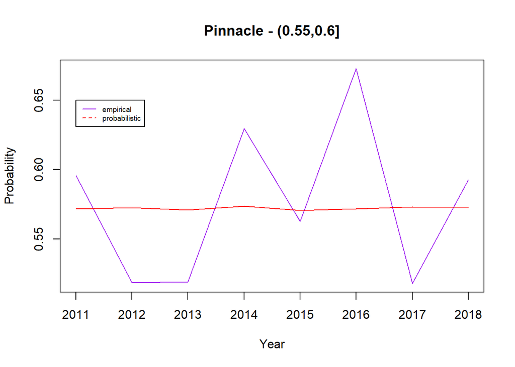

*Figure 15 : Fraction (empirical) vs implied probability (probabilistic) for Pinnacle for corresponding bin.*

There is again huge variation between implied probability and fraction because off the small size of data. However, Pinnacle seems to be accurate for determining odds ( or probability for over ) in 2011,2015 and 2018.

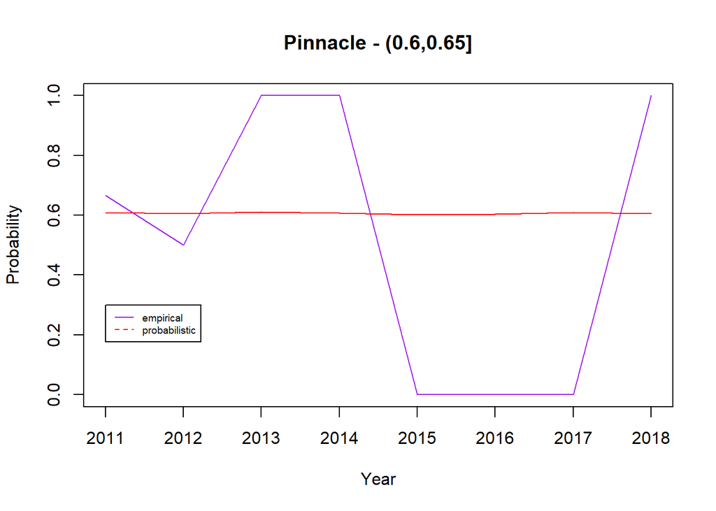

*Figure 16 : Fraction (empirical) vs implied probability (probabilistic) for Pinnacle for corresponding bin.*

In years 2013, 2014, 2015, 2016 and 2017, 2018 the values of fraction are not meaningful since the data for corresponding bin is too small. However, in years 2011 and 2012, Pinnacle is good at determining over odds.

Since the last two graphs are not useful for evaluating the performance of bookmaker, it is reasonable to combine these two bins. In other words, the new bin is (0.55,0.65]. Then the new plot will be;

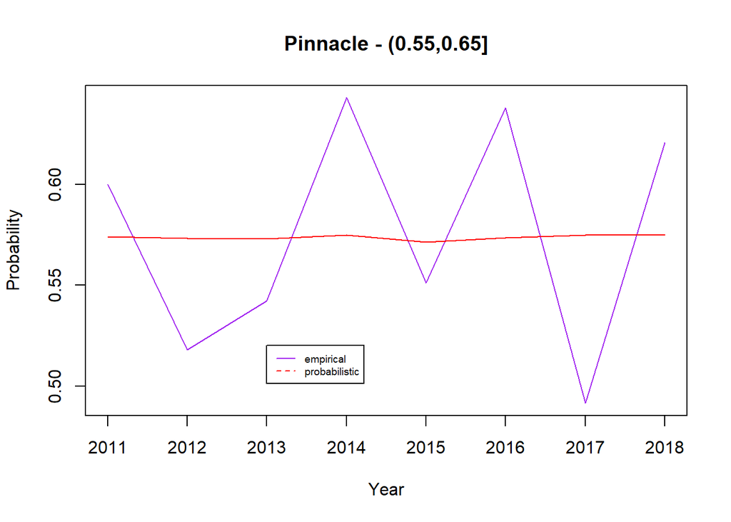

*Figure 17 : Fraction (empirical) vs implied probability (probabilistic) for Pinnacle for corresponding bin.*

In this graph, it can be seen that the prediction of Pinnacle for the bin (0.55,0.65] is quite accurate in 2011, 2014, 2015, 2016 and 2018 since the fractions are between the boundaries of corresponding bin ( (0.55,0.65] ). In the remaining years, there are some variations; however, in general, its performance can be accepted as good. Moreover, evaluation from this graph is more sensible to comment according to this graph since the data is larger

#### 3.) Task 2

In this task, odd change in percentage between initial and final odds were analyzed for the performance of bookmaker, and visualizations were suggested. First of all, 10Bet was selected as test bookmaker to analyze its performance on changing odds. In this task, odds for homewin was the case and the data manipulation was carried out according to the change in homewin odds. Match results was obtained from the data and a column was created as “Result_Home” which takes the value of 1 if the match result is 1 (homewin), -1 otherwise. Then the “Odd_change_percent” column was created which shows the percentage of odd change for home win, and these values were divided into bins. In other words, it is the difference between starting and final odds in percentage. Then “Bookmaker_prediction” column was also created which has value of 1 if the bookmaker’s prediction is true, 0 otherwise. At this point, bookmaker’s prediction is based on its changes on odds. For example, if it decreases the odd of homewin, this means that the bookmaker thinks that home team will probably win the game. If the home team will win the match, the prediction of bookmaker is true, or vice versa.

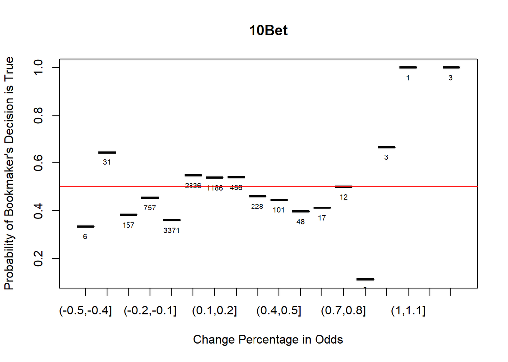

*Figure 18: Probability of correctness of the bookmaker’s decision for each bin*

#### 4.) APPENDİX: R Codes

```
install.packages("data.table")
install.packages("anytime")
require(data.table)
require(anytime)

matches_file_path='C:/Users/AHMET/Desktop/IE 582/Homework 1/IE582Fall2018_project_files/df9b1196-e3cf-4cc7-9159-f236fe738215_matches.rds'
odd_details_file_path='C:/Users/AHMET/Desktop/IE 582/Homework 1/IE582Fall2018_project_files/df9b1196-e3cf-4cc7-9159-f236fe738215_odd_details.rds'

matches=readRDS(matches_file_path)

odds=readRDS(odd_details_file_path)

matches=unique(matches)

#transform unix time to date
matches[,match_date:=anydate(date)]
#transform unix time to date time
matches[,match_time:=anytime(date)]

#order by home team and match date (decreasing)
matches=matches[order(home,-match_time)]

#only one column deletion
matches[,date:=NULL]

#matches[,3,with=F]

matches[,c("HomeGoals","AwayGoals"):=tstrsplit(score,':')]

matches[,Year:=year(match_time)]
matches[,Month:=month(match_time)]
matches[,Weekday:=wday(match_time)]
matches[,Hour:=hour(match_time)]

#transform characters to numeric for scores
matches$HomeGoals=as.numeric(matches$HomeGoals)
matches[,AwayGoals:=as.numeric(AwayGoals)]

#calculate total goals
matches[,TotalGoals:=HomeGoals+AwayGoals]
```

[output cut: 495 more lines]

```
odds_1x2_total[,Result_Home:=-1]
odds_1x2_total[HomeGoals-AwayGoals>0,Result_Home:=1] #Result_Home=1 if result is one, -1 otherwise
odds_1x2_total[,Bookmaker_prediction:=0]
odds_1x2_total[Odd_change_percent*Result_Home<0,Bookmaker_prediction:=1] #+1 is true, while 0 represents false

cutpoints=seq(-0.5,1.3,0.1)
odds_1x2_total[,odds_cut_1x2:=cut(Odd_change_percent,cutpoints)]
#odds_1x2_total[,odds_cut_1x2:=NULL]
x<-mean(odds_1x2_total[odds_cut_1x2=="(-0.5,-0.4]",Bookmaker_prediction])

a<-odds_1x2_total[, .(count = .N, var = sum(Bookmaker_prediction)), by = odds_cut_1x2]
a[,mean:=var/count]
plot(a$odds_cut_1x2,a$mean,xlab="Change Percentage in Odds",ylab="Probability of Bookmaker's Decision is True",main="10Bet")
text(a$odds_cut_1x2,a$mean, labels=a$count, cex= 0.6, pos=1)
abline(0.5,0,col='red')
```